# UConn SCS Fall 2021 Workshop Series

The SCS Team

2021-09-30

It is impossible to be an expert in all aspects of science, mathematics, statistics, business, communication, psychology and all the other myriad skills necessary to solve complex problems in the real world. UConn’s Statistical Consulting Services aims to bridge the gap between statisticians and domain experts from across disciplines at UConn and across Connecticut. We provide statistical support in the form of [consultations](https://statsconsulting.uconn.edu/), seminars and workshops.

### Aims of this workshop series

The aims of this workshop series are to (i) introduce participants to statistical tools available in R, (ii) promote the use of R by participants in their own work and research, and (iii) promote reproducible research through making all code and workshop content freely available to all participants.

### What’s on this page

This page is going to guide you through **steps to take** to prepare for the upcoming workshops. The primary goals are to:

1. Have each participant ready to use R and Rstudio, and
2. Provide practical tips on how to prepare for the workshops.

### Workshop Survey

Before participating in one of our workshops please [register here](https://statsconsulting.uconn.edu/workshop-schedule/) (you do not need to register again if you have already), and complete our [pre-workshop survey](https://docs.google.com/forms/d/e/1FAIpQLSfMo0TcrzJGHsD57B9HhABmpXL-GoH5yQAHC0CufJp7HGSCaw/viewform?usp=sf_link). This **survey** is a valuable tool, allowing us to ensure that you get the most out of our workshops.

### Live Coding

Similar to a [Software or Data Carpentry workshop](https://carpentries.org/), instructors will work through the workshop with participants, typing in the code, reformatting data, and talking as we go. This is called “live coding”. However, the instructor is not live coding in a vacuum. Importantly, participants are strongly encouraged to “code-along” with the instructor. We refer to the practice of having the instructor live code and the learners code along as “participatory live coding” or, less formally, ‘code-along sessions’. For some suggestions on how to format you screen, see below.

## Workshop Preparation

### Before the workshop

1. Complete our [pre-workshop survey](https://docs.google.com/forms/d/e/1FAIpQLSfMo0TcrzJGHsD57B9HhABmpXL-GoH5yQAHC0CufJp7HGSCaw/viewform?usp=sf_link)
2. Make sure that you have downloaded and installed R and Rstudio
3. Work through the introduction to R and Rstudio section on this page
4. Install the packages listed in the Installing & loading packages
5. Ensure that you are comfortable opening an R script and loading packages
6. Check that you are able to access and operate [WebEx](https://confluence.uconn.edu/ikb/communication-and-collaboration/webex-video-conferencing/hosting-or-joining-a-webex-meeting)
7. If you have any questions/issues please schedule an appointment with one of the SCS consulants, [available here](https://statsconsulting.uconn.edu/walk-in-schedule/), or email timothy.e.moore@uconn.edu

### During the workshop

1. Sign in on our registration form.
2. It is hard to keep track of everything on your screen, especially if you only have a single monitor. If you are in this situation, we recommend having as few programs open on your screen as possible. We recommend splitting your layout so that you have your Rstudio session on one side of your screen, and WebEx on the other side of the screen:

[figure not shown]

### After the workshop

1. Let us know how we did! Please complete our [post-workshop survey](https://docs.google.com/forms/d/e/1FAIpQLSfaUs9ibczmT_7Wsm_6-gLK7YWS4WlpcWC6unJ7fBINNH-5Rw/viewform?usp=sf_link)
2. Reach out to timothy.e.moore@uconn.edu if you have any questions, or recommendations for future workshops.

## Getting started with R and Rstudio

### Installing R and Rstudio

#### Windows

Install **R** by downloading and running [this .exe](https://cran.r-project.org/bin/windows/base/release.htm) file from [CRAN](https://cran.r-project.org/index.html). Also, please install the **RStudio** [IDE](https://www.rstudio.com/products/rstudio/download/#download). Note that if you have separate user and admin accounts, you should run the installers as administrator (right-click on .exe file and select “Run as administrator” instead of double-clicking). Otherwise problems may occur later, for example when installing R packages.

#### MacOS

Install **R** by downloading and running [this .pkg file](https://cran.r-project.org/bin/macosx/R-latest.pkg) from [CRAN](https://cran.r-project.org/index.html). Also, please install the **RStudio** [IDE](https://www.rstudio.com/products/rstudio/download/#download).

#### Linux

You can download the binary files for your distribution from CRAN. Or you can use your package manager (e.g. for Debian/Ubuntu run ‘sudo apt-get install r-base’ and for Fedora run ‘sudo dnf install R’). Also, please install the **RStudio** [IDE](https://www.rstudio.com/products/rstudio/download/#download).

- **Note for the power analysis workshops:** Install **G*Power** by following the links on [this page](https://www.psychologie.hhu.de/arbeitsgruppen/allgemeine-psychologie-und-arbeitspsychologie/gpower.html), depending on your native OS.

### A brief intro to R and Rstudio

*This content has been adapted from a [Carpentries](https://carpentries.org/) lesson. For more detail visit [this website](https://swcarpentry.github.io/r-novice-gapminder/01-rstudio-intro/).

#### What is Rstudio?

Rstudio is a free, open source R Integrated Development Environment (IDE). It provides a built in editor, works on all platforms (including on servers) and provides many advantages such as integration with version control (e.g., git) and project management. Essentially, it is the interface we will use to communicate with R.

#### Basic layout of RStudio

When you first open RStudio, you will be greeted by three panels:

- The interactive R console/Terminal (entire left)
- Environment/History/Connections (tabbed in upper right)
- Files/Plots/Packages/Help/Viewer (tabbed in lower right):

[figure not shown]

One option for working in **Rstudio** would be to write all of our R commands directly into the *console*. One of the benefits of **Rstudio**, though is that we can store all of our commands in a document, or *script*, which we can then share with collaborators or publish along with our research. In fact, we can use documents generated in **R** and **Rstudio** to build webpages (like this one!).

To open a new *R script* go to File > New File > R Script. Now, the **Rstudio** window should have four panels, like this:

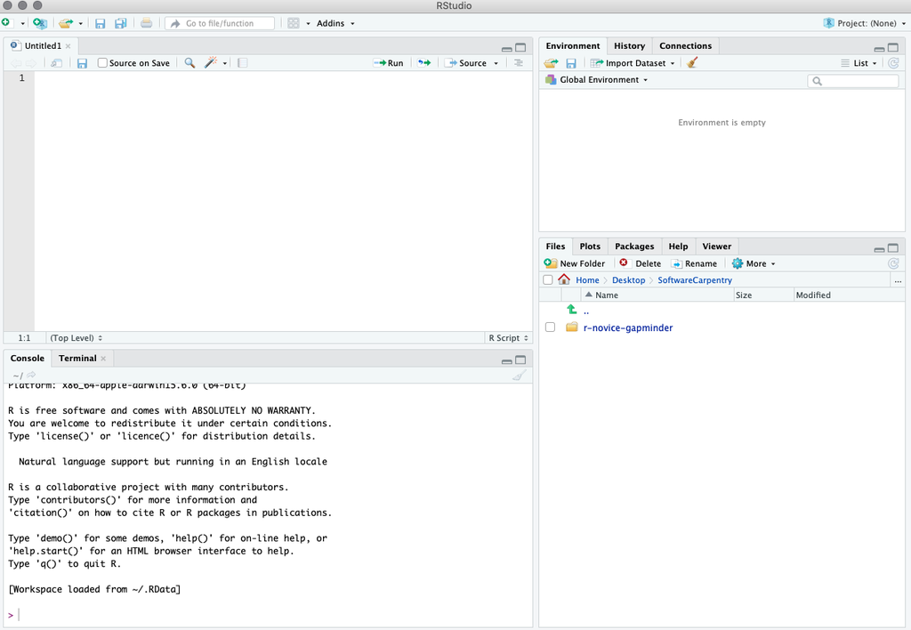

All of you code can now be written in this script and saved on your computer for later. Next we will run through some basics of R syntax.

### Introduction to R

Now that we have opened a new R script, we can begin writing commands and sending them to R to be executed. Each line of code that we run will be printed in the console, next to the ‘>’. R will then evaluate the command and try to execute it. Some of the simplest commands are for using R like a calculator. For example, type ‘1 + 100’ into your R script.

```r
1 + 100
```

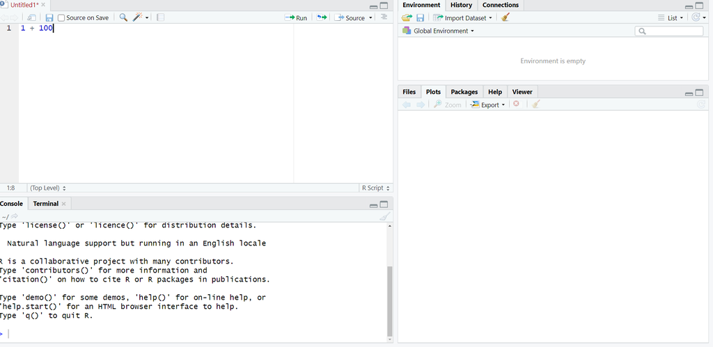

Right now, the command only exists in the R script and has not been sent to R. There are two main ways of sending commands from your R script to R:

- By placing your cursor on the line you want to run and clicking on the ‘run’ button on the top right-hand side of the script pane:

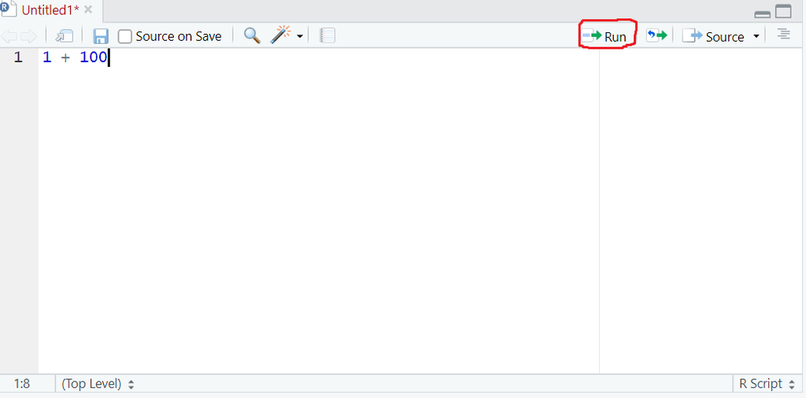

- Alternatively, you can use either ‘Cmd + Enter’ (on a Mac), or ‘Ctrl + Enter’ (on a Windows machine) to execute the line that your cursor is on.

Once you have run the command you should see the command, and R’s response, show up in the Console pane:

[figure not shown]

Here, R has evaluated your command, and executed the arithmetic and output the result.

You can also highlight multiple lines in your R script and run them simultaneously, using one of the options above:

```r
1 + 100

10*20

(5+3) / 2
```

[figure not shown]

In this case, R has executed all three commands, and output the results in the order they appeared in your R script.

##### Storing values in variables

We can store values in variables using the assignment operator ‘<-’, like this:

```r
x <- 1/4
```

Now, we will see that an object ‘x’ has appeared in our environment tab.

[figure not shown]

We have essentially stored the number `0.25` in the object ‘x’. We can now execute any commands on ‘x’ that expect a number:

```r
1 + x
```

[figure not shown]

We can store multiple values in an object, for example:

```r
x <- c(10, 15, 20)
```

[figure not shown]

(notice that we have now overwritten the previous value of ‘x’)

We can now perform functions on the object x, for example, arithmetic:

```r
x + 5
```

[figure not shown]

Or more advanced functions, like calculating the mean:

```r
mean(x)
```

[figure not shown]

##### Installing & loading packages

So far, the arithmetic and other functions (like `mean()`) we have used are built into base R. There are many functions that have been developed to perform statistical analysis, data manipulations, and data visualizations and these are stored in stand-alone **packages**. Essentially these packages are collections of functions (to use a Harry Potter analogy: packages are the spell books and functions are spells). We will use a number of these packages in this workshop. We encourage all participants to install these prior to attending the workshops.

There are 2 steps to using packages in R: i) installing them onto your machine, and ii) loading them into your R session.

For the first step, you can use the `install.packages` function. For these workshops, we will install serveral packages. To begin, install `ggplot2`:

[figure not shown]

```r
install.packages("ggplot2")
```

```r
installed.packages()
```

To make the packages available to in the current session, you need to use the `library()` function. Note this will only work on installed packages. You will need to load packages each time you start a new Rstudio session.

[figure not shown]

```r
library(ggplot2)
```

Some very useful packages that we recommend you install prior to attending our workshops inlcude:

- ggplot2
- AMR
- dplyr
- cowplot
- gridExtra
- corrplot
- GGally
- sjPlot